# Data Analysis Process

## Scenario

**About the company**

Bellabeat, founded in 2013, is a high-tech company that makes smart health-focused products. A company that targets women, it has grown rapidly and by 2016 it had opened offices around the world and launched different products. Their products collect data on activity, sleep, stress and health, which allows Bellabeat to inform women about their health and habits.

**About the product**

This case study involves an analysis of the Bellabeat app product. The Bellabeat app provides users with health data related to their activity, sleep, stress, menstrual cycle, and mindfulness habits. This data can help users better understand their current habits and make healthy decisions. The Bellabeat app connects to their line of smart wellness products.

## Ask

**Business task**

Analyse Bellabeat app product data and find trends in order to gain insights into how consumers use the Bellabeat product. From these findings make recommendations on how these trends would help Bellabeat’s marketing strategy.

These questions will guide our analysis:

- What are some trends in smart device usage?
- How could these trends apply to Bellabeat customers?
- How could these trends help influence Bellabeat marketing strategy?

**Key stakeholders**

- **Urška Sršen:** Bellabeat’s cofounder and Chief Creative Officer.
- **Sando Mur:** Bellabeat’s cofounder and key member of the Bellabeat executive team.
- **Bellabeat marketing analytics team:** A team of data analysts responsible for collecting, analysing, and reporting data that helps guide Bellabeat’s marketing strategy.

## Prepare

**Information about dataset**

This case study will be used the FitBit Fitness Tracker Data. [The dataset](https://www.kaggle.com/datasets/arashnic/fitbit) is provided by Mobius and stored on Kaggle. This dataset contains personal fitness tracker and was generated by respondents of a survey distributed via Amazon Mechanical Turk between 03.12.2016 - 05.12.2016.

**Information about licensing, privacy, security and accessibility of the dataset:** it was verified that the dataset used is public domain and 30 eligible Fitbit users consented to the submission of personal tracker data, including minute-level output for physical activity, heart rate, and sleep monitoring. It includes information about daily activity, steps, and heart rate that can be used to explore users’ habits.

**Data organisation**

The dataset is organised into 18 CSV files that contain different variables and observations. In order to answer some questions as to whether the data are accurate, consistent, reliable, and in addition whether the data have limitations or problems with bias, we analysed each file in Google Sheets and created a pivot table to check the content (fields and values), the tracking period and the amount of users (ID) available for analysis.

In the following table, all summarised information can be found:

```r
# importing and creating a dataframe with dataset organization summary

library(readr) #for read in large flat files

dataset_organization_summary <- read_csv("dataset_organization_summary.csv", show_col_types = FALSE)

# displaying dataframe as table with additional formatting using knitr package and kable function

library(dplyr) #for data manipulation
library(knitr)
library(kableExtra)

dataset_organization_summary %>% kable(align = "l") %>%
                            kable_styling(full_width = FALSE, bootstrap_options = "striped")
```

| Number | File Name | Content - Fields | Information |
| --- | --- | --- | --- |
| 1 | dailyActivity_merged | ID, Activity Day, Steps, Distance, Distance by level ( Very, Moderately, Light, Sedentary), Active by level in minutes(Very, Fairly, Lightly, Sedentary) and Calories | Tracking activity between 4 - 5/12/2016 by 33 users. |
| 2 | dailyCalories_merged | ID, Activity Day and Calories | Tracking activity between 4 - 5/12/2016 by 33 users. |
| 3 | dailyIntensities_merged | ID, Activity Day, Distance by level ( Very, Moderately, Light, Sedentary) and Active by level in minutes(Very, Fairly, Lightly, Sedentary) | Tracking activity between 4 - 5/12/2016 by 33 users. |
| 4 | dailySteps_merged | ID, Activity Day and Steps | Tracking activity between 4 - 5/12/2016 by 33 users. |
| 5 | heartrate_seconds_merged | ID, Tracking (date + time) by seconds and Heart rate value | Tracking activity between 4 - 5/12/2016 by 14 users. |
| 6 | hourlyCalories_merged | ID, Activity (date + time) by hour and Calories | Tracking activity between 4 - 5/12/2016 by 33 users. |
| 7 | hourlyIntensities_merged | ID, Activity (date + time) by hour and Intensity (total and average) | Tracking activity between 4 - 5/12/2016 by 33 users. |
| 8 | hourlySteps_merged | ID, Activity (date + time) by hour and Total steps | Tracking activity between 4 - 5/12/2016 by 33 users. |
| 9 | minuteCaloriesNarrow_merged | ID, Activity (date + time) by minute and Calories *Narrow form | Tracking activity between 4 - 5/12/2016 by 33 users. |
| 10 | minuteCaloriesWide_merged | ID, Activity (date + time) by minute and Calories *Wide form | Tracking activity between 4/13 - 5/13/2016 by 33 users. |
| 11 | minuteIntensitiesNarrow_merged | ID, Activity(date + time) by minute and Intensity *Narrow form | Tracking activity between 4 - 5/12/2016 by 33 users. |
| 12 | minuteIntensitiesWide_merged | ID, Activity(date + time) by minute and Intensity *WIDe form | Tracking activity between 4/13 - 5/13/2016 by 33 users. |
| 13 | minuteMETsNarrow_merged | ID, Activity(date + time) by minute and METs value (metabolic equivalent) | Tracking activity between 4 - 5/12/2016 by 33 users. |
| 14 | minuteSleep_merged | ID, Tracking(date + time) by minute, Value and logID | Tracking activity between 4/11 - 5/12/2016 by 24 users. |
| 15 | minuteStepsNarrow_merged | ID, Activity (date + time) by minute and Steps *Narrow form | Tracking activity between 4 - 5/12/2016 by 33 users. |
| 16 | minuteStepsWide_merged | ID, Activity (date + time) by minute and Steps *WIDe form | Tracking activity between 4/13 - 5/13/2016 by 33 users. |
| 17 | sleepDay_merged | ID, Sleep day (date + time), Total sleeps records, Total in minutes (asleep and in bed) | Tracking activity between 4/12 - 5/12/2016 by 24 users. |
| 18 | weightLogInfo_merged | ID, Tracking(date + time), Weight in kg and Pounds, Fat, BMI, Manual report and LogID | Tracking activity between 4/12 - 5/12/2016 by 8 users. |

From these limitations, we decided not to continue in the next step by analysing some datasets, Nr. 2,3,4,5, 9, 10, 11, 12, 13, 14, 15, 16 and 18. Even with these limitations, the datasets we will be focusing on, still remain useful on finding trends in user behavior and making predictions that can help Bellabeat’s marketing team.

## Process

In this case study, R language will be used to clean, transform and visualise data.

**Setting up the environment**

First of all, we started to install and loading important packages in R Studio.

```r
#Setting up my environment

library(tidyverse) # important package for data analysis
library(lubridate) # important package to work with dates and times

library(tidyr) # a framework for creating and shaping tidy data
library(dplyr) # for data manipulation
library(scales) # converting from data values to perceptual properties
library(ggplot2) #for data visualization
```

**Importing datasets**

In the data organisation step it was verified that some datasets had some limitations for analysis, in this way we selected some important datasets to start the cleaning process, such as:

- dailyActivity_merged
- hourlyCalories_merged
- hourlyIntensities_merged
- hourlySteps_merged
- sleepDay_merged

```r
#Importing and creating dataframes

daily_activity <- read_csv("dailyActivity_merged.csv")

hourly_calories <- read_csv("hourlyCalories_merged.csv")
hourly_intensities <- read_csv("hourlyIntensities_merged.csv")
hourly_steps <- read_csv("hourlySteps_merged.csv")

day_sleep <- read_csv("sleepDay_merged.csv")
```

After that, to view dataframes and check the structure of dataframes, data type and column names, ‘str() function’ is used to check these information:

```r
#Preview of dataframes

str(daily_activity)
```

```
## spc_tbl_ [940 × 15] (S3: spec_tbl_df/tbl_df/tbl/data.frame)
##  $ Id                      : num [1:940] 1.5e+09 1.5e+09 1.5e+09 1.5e+09 1.5e+09 ...
##  $ ActivityDate            : chr [1:940] "4/12/2016" "4/13/2016" "4/14/2016" "4/15/2016" ...
##  $ TotalSteps              : num [1:940] 13162 10735 10460 9762 12669 ...
##  $ TotalDistance           : num [1:940] 8.5 6.97 6.74 6.28 8.16 ...
##  $ TrackerDistance         : num [1:940] 8.5 6.97 6.74 6.28 8.16 ...
##  $ LoggedActivitiesDistance: num [1:940] 0 0 0 0 0 0 0 0 0 0 ...
##  $ VeryActiveDistance      : num [1:940] 1.88 1.57 2.44 2.14 2.71 ...
##  $ ModeratelyActiveDistance: num [1:940] 0.55 0.69 0.4 1.26 0.41 ...
##  $ LightActiveDistance     : num [1:940] 6.06 4.71 3.91 2.83 5.04 ...
##  $ SedentaryActiveDistance : num [1:940] 0 0 0 0 0 0 0 0 0 0 ...
##  $ VeryActiveMinutes       : num [1:940] 25 21 30 29 36 38 42 50 28 19 ...
##  $ FairlyActiveMinutes     : num [1:940] 13 19 11 34 10 20 16 31 12 8 ...
##  $ LightlyActiveMinutes    : num [1:940] 328 217 181 209 221 164 233 264 205 211 ...
##  $ SedentaryMinutes        : num [1:940] 728 776 1218 726 773 ...
##  $ Calories                : num [1:940] 1985 1797 1776 1745 1863 ...
##  - attr(*, "spec")=
##   .. cols(
##   ..   Id = col_double(),
##   ..   ActivityDate = col_character(),
##   ..   TotalSteps = col_double(),
##   ..   TotalDistance = col_double(),
##   ..   TrackerDistance = col_double(),
##   ..   LoggedActivitiesDistance = col_double(),
##   ..   VeryActiveDistance = col_double(),
##   ..   ModeratelyActiveDistance = col_double(),
##   ..   LightActiveDistance = col_double(),
##   ..   SedentaryActiveDistance = col_double(),
##   ..   VeryActiveMinutes = col_double(),
##   ..   FairlyActiveMinutes = col_double(),
##   ..   LightlyActiveMinutes = col_double(),
##   ..   SedentaryMinutes = col_double(),
##   ..   Calories = col_double()
##   .. )
##  - attr(*, "problems")=<externalptr>
```

```r
str(hourly_calories)
```

```
## spc_tbl_ [22,099 × 3] (S3: spec_tbl_df/tbl_df/tbl/data.frame)
##  $ Id          : num [1:22099] 1.5e+09 1.5e+09 1.5e+09 1.5e+09 1.5e+09 ...
##  $ ActivityHour: chr [1:22099] "4/12/2016 12:00:00 AM" "4/12/2016 1:00:00 AM" "4/12/2016 2:00:00 AM" "4/12/2016 3:00:00 AM" ...
##  $ Calories    : num [1:22099] 81 61 59 47 48 48 48 47 68 141 ...
##  - attr(*, "spec")=
##   .. cols(
##   ..   Id = col_double(),
##   ..   ActivityHour = col_character(),
##   ..   Calories = col_double()
##   .. )
##  - attr(*, "problems")=<externalptr>
```

```r
str(hourly_intensities)
```

```
## spc_tbl_ [22,099 × 4] (S3: spec_tbl_df/tbl_df/tbl/data.frame)
##  $ Id              : num [1:22099] 1.5e+09 1.5e+09 1.5e+09 1.5e+09 1.5e+09 ...
##  $ ActivityHour    : chr [1:22099] "4/12/2016 12:00:00 AM" "4/12/2016 1:00:00 AM" "4/12/2016 2:00:00 AM" "4/12/2016 3:00:00 AM" ...
##  $ TotalIntensity  : num [1:22099] 20 8 7 0 0 0 0 0 13 30 ...
##  $ AverageIntensity: num [1:22099] 0.333 0.133 0.117 0 0 ...
##  - attr(*, "spec")=
##   .. cols(
##   ..   Id = col_double(),
##   ..   ActivityHour = col_character(),
##   ..   TotalIntensity = col_double(),
##   ..   AverageIntensity = col_double()
##   .. )
##  - attr(*, "problems")=<externalptr>
```

```r
str(hourly_steps)
```

```
## spc_tbl_ [22,099 × 3] (S3: spec_tbl_df/tbl_df/tbl/data.frame)
##  $ Id          : num [1:22099] 1.5e+09 1.5e+09 1.5e+09 1.5e+09 1.5e+09 ...
##  $ ActivityHour: chr [1:22099] "4/12/2016 12:00:00 AM" "4/12/2016 1:00:00 AM" "4/12/2016 2:00:00 AM" "4/12/2016 3:00:00 AM" ...
##  $ StepTotal   : num [1:22099] 373 160 151 0 0 ...
##  - attr(*, "spec")=
##   .. cols(
##   ..   Id = col_double(),
##   ..   ActivityHour = col_character(),
##   ..   StepTotal = col_double()
##   .. )
##  - attr(*, "problems")=<externalptr>
```

```r
str(day_sleep)
```

```
## spc_tbl_ [413 × 5] (S3: spec_tbl_df/tbl_df/tbl/data.frame)
##  $ Id                : num [1:413] 1.5e+09 1.5e+09 1.5e+09 1.5e+09 1.5e+09 ...
##  $ SleepDay          : chr [1:413] "4/12/2016 12:00:00 AM" "4/13/2016 12:00:00 AM" "4/15/2016 12:00:00 AM" "4/16/2016 12:00:00 AM" ...
##  $ TotalSleepRecords : num [1:413] 1 2 1 2 1 1 1 1 1 1 ...
##  $ TotalMinutesAsleep: num [1:413] 327 384 412 340 700 304 360 325 361 430 ...
##  $ TotalTimeInBed    : num [1:413] 346 407 442 367 712 320 377 364 384 449 ...
##  - attr(*, "spec")=
##   .. cols(
##   ..   Id = col_double(),
##   ..   SleepDay = col_character(),
##   ..   TotalSleepRecords = col_double(),
##   ..   TotalMinutesAsleep = col_double(),
##   ..   TotalTimeInBed = col_double()
##   .. )
##  - attr(*, "problems")=<externalptr>
```

**Cleaning process**

Before merging some datasets to work better in later steps, it is a good practice to make sure the data is clean. First, we started checking for duplicates and NA values (“NOT available”), then we removed them. After that, we examined how many unique IDs per dataframe we have to work with.

```r
#Checking for duplicates

sum(duplicated(daily_activity))
```

```
## [1] 0
```

```r
sum(duplicated(hourly_calories))
```

```
## [1] 0
```

```r
sum(duplicated(hourly_intensities))
```

```
## [1] 0
```

```r
sum(duplicated(hourly_steps))
```

```
## [1] 0
```

```r
sum(duplicated(day_sleep))
```

```
## [1] 3
```

```r
#Checking for NA values

sum(is.na(daily_activity))
```

```
## [1] 0
```

```r
sum(is.na(hourly_calories))
```

```
## [1] 0
```

```r
sum(is.na(hourly_intensities))
```

```
## [1] 0
```

```r
sum(is.na(hourly_steps))
```

```
## [1] 0
```

```r
sum(is.na(day_sleep))
```

```
## [1] 0
```

From these results, we need to remove 3 duplicates in the day_sleep dataframe and check again if it still has duplicates.

```r
#Removing duplicates in dataframe

day_sleep <- day_sleep %>%
  distinct()

#Checking for duplicate in day_sleep dataframe

sum(duplicated(day_sleep))
```

```
## [1] 0
```

Now we need to sure about how many unique user IDs we have.

```r
#Checking how many unique user IDs

n_distinct(daily_activity$Id)
```

```
## [1] 33
```

```r
n_distinct(hourly_calories$Id)
```

```
## [1] 33
```

```r
n_distinct(hourly_intensities$Id)
```

```
## [1] 33
```

```r
n_distinct(hourly_steps$Id)
```

```
## [1] 33
```

```r
n_distinct(day_sleep$Id)
```

```
## [1] 24
```

**Transforming data**

In order to have consistency in the column names and data-time format, in this step we will do some manipulations, such as checking the column names in the dataframe, renaming columns (if necessary), changing formats and separating date-time column.

```r
#Checking the column names

colnames(daily_activity)
```

```
##  [1] "Id"                       "ActivityDate"
##  [3] "TotalSteps"               "TotalDistance"
##  [5] "TrackerDistance"          "LoggedActivitiesDistance"
##  [7] "VeryActiveDistance"       "ModeratelyActiveDistance"
##  [9] "LightActiveDistance"      "SedentaryActiveDistance"
## [11] "VeryActiveMinutes"        "FairlyActiveMinutes"
## [13] "LightlyActiveMinutes"     "SedentaryMinutes"
## [15] "Calories"
```

```r
colnames(hourly_calories)
```

```
## [1] "Id"           "ActivityHour" "Calories"
```

```r
colnames(hourly_intensities)
```

```
## [1] "Id"               "ActivityHour"     "TotalIntensity"   "AverageIntensity"
```

```r
colnames(hourly_steps)
```

```
## [1] "Id"           "ActivityHour" "StepTotal"
```

```r
colnames(day_sleep)
```

```
## [1] "Id"                 "SleepDay"           "TotalSleepRecords"
## [4] "TotalMinutesAsleep" "TotalTimeInBed"
```

```r
#Rename the column name “SleepDay” to “ActivityDate” in day_sleep dataframe

day_sleep <- rename(day_sleep, ActivityDate = SleepDay)
colnames(day_sleep)
```

```
## [1] "Id"                 "ActivityDate"       "TotalSleepRecords"
## [4] "TotalMinutesAsleep" "TotalTimeInBed"
```

The next step is to change the format in the date-time field. In previous, when checking dataframe structure it was seen that these fields are as chr(character type), so it is necessary to change the fields to date type. In this situation we used ‘as.Date() function’ and ‘as.POSIXct()’ (when there are time components). To split the date/time column the ‘separate() function’ was used.

```r
#Formatting date field, <chr> into <date>
##Separating date-time column dataframe

daily_activity_clean <- daily_activity %>%
  mutate(ActivityDate = as.Date(ActivityDate, "%m/%d/%Y"))

day_sleep_clean <- day_sleep %>%
  mutate(ActivityDate = as.Date(ActivityDate, "%m/%d/%Y"))

#hourly dataframe

hourly_calories_clean <- hourly_calories %>%
  mutate(ActivityHour = as.POSIXct(ActivityHour,format="%m/%d/%Y %I:%M:%S %p", tz=Sys.timezone())) %>%
  separate(ActivityHour, c("ActivityDate", "ActivityHour"), sep= " ") %>%
  mutate(ActivityDate = as.Date(ActivityDate, "%Y-%m-%d"))

hourly_intensities_clean <- hourly_intensities %>%
  mutate(ActivityHour = as.POSIXct(ActivityHour,format="%m/%d/%Y %I:%M:%S %p", tz=Sys.timezone())) %>%
  separate(ActivityHour, c("ActivityDate", "ActivityHour"), sep= " ") %>%
  mutate(ActivityDate = as.Date(ActivityDate, "%Y-%m-%d"))

hourly_steps_clean <- hourly_steps %>%
  mutate(ActivityHour = as.POSIXct(ActivityHour,format="%m/%d/%Y %I:%M:%S %p", tz=Sys.timezone())) %>%
  separate(ActivityHour, c("ActivityDate", "ActivityHour"), sep= " ") %>%
  mutate(ActivityDate = as.Date(ActivityDate, "%Y-%m-%d"))
```

```r
#checking the modifications

glimpse(daily_activity_clean)
```

```
## Rows: 940
## Columns: 15
## $ Id                       <dbl> 1503960366, 1503960366, 1503960366, 150396036…
## $ ActivityDate             <date> 2016-04-12, 2016-04-13, 2016-04-14, 2016-04-…
## $ TotalSteps               <dbl> 13162, 10735, 10460, 9762, 12669, 9705, 13019…
## $ TotalDistance            <dbl> 8.50, 6.97, 6.74, 6.28, 8.16, 6.48, 8.59, 9.8…
## $ TrackerDistance          <dbl> 8.50, 6.97, 6.74, 6.28, 8.16, 6.48, 8.59, 9.8…
## $ LoggedActivitiesDistance <dbl> 0, 0, 0, 0, 0, 0, 0, 0, 0, 0, 0, 0, 0, 0, 0, …
## $ VeryActiveDistance       <dbl> 1.88, 1.57, 2.44, 2.14, 2.71, 3.19, 3.25, 3.5…
## $ ModeratelyActiveDistance <dbl> 0.55, 0.69, 0.40, 1.26, 0.41, 0.78, 0.64, 1.3…
## $ LightActiveDistance      <dbl> 6.06, 4.71, 3.91, 2.83, 5.04, 2.51, 4.71, 5.0…
## $ SedentaryActiveDistance  <dbl> 0, 0, 0, 0, 0, 0, 0, 0, 0, 0, 0, 0, 0, 0, 0, …
## $ VeryActiveMinutes        <dbl> 25, 21, 30, 29, 36, 38, 42, 50, 28, 19, 66, 4…
## $ FairlyActiveMinutes      <dbl> 13, 19, 11, 34, 10, 20, 16, 31, 12, 8, 27, 21…
## $ LightlyActiveMinutes     <dbl> 328, 217, 181, 209, 221, 164, 233, 264, 205, …
## $ SedentaryMinutes         <dbl> 728, 776, 1218, 726, 773, 539, 1149, 775, 818…
## $ Calories                 <dbl> 1985, 1797, 1776, 1745, 1863, 1728, 1921, 203…
```

```r
glimpse(hourly_calories_clean)
```

```
## Rows: 22,099
## Columns: 4
## $ Id           <dbl> 1503960366, 1503960366, 1503960366, 1503960366, 150396036…
## $ ActivityDate <date> 2016-04-12, 2016-04-12, 2016-04-12, 2016-04-12, 2016-04-…
## $ ActivityHour <chr> "00:00:00", "01:00:00", "02:00:00", "03:00:00", "04:00:00…
## $ Calories     <dbl> 81, 61, 59, 47, 48, 48, 48, 47, 68, 141, 99, 76, 73, 66, …
```

```r
glimpse(hourly_intensities_clean)
```

```
## Rows: 22,099
## Columns: 5
## $ Id               <dbl> 1503960366, 1503960366, 1503960366, 1503960366, 15039…
## $ ActivityDate     <date> 2016-04-12, 2016-04-12, 2016-04-12, 2016-04-12, 2016…
## $ ActivityHour     <chr> "00:00:00", "01:00:00", "02:00:00", "03:00:00", "04:0…
## $ TotalIntensity   <dbl> 20, 8, 7, 0, 0, 0, 0, 0, 13, 30, 29, 12, 11, 6, 36, 5…
## $ AverageIntensity <dbl> 0.333333, 0.133333, 0.116667, 0.000000, 0.000000, 0.0…
```

```r
glimpse(hourly_steps_clean)
```

```
## Rows: 22,099
## Columns: 4
## $ Id           <dbl> 1503960366, 1503960366, 1503960366, 1503960366, 150396036…
## $ ActivityDate <date> 2016-04-12, 2016-04-12, 2016-04-12, 2016-04-12, 2016-04-…
## $ ActivityHour <chr> "00:00:00", "01:00:00", "02:00:00", "03:00:00", "04:00:00…
## $ StepTotal    <dbl> 373, 160, 151, 0, 0, 0, 0, 0, 250, 1864, 676, 360, 253, 2…
```

```r
glimpse(day_sleep_clean)
```

```
## Rows: 410
## Columns: 5
## $ Id                 <dbl> 1503960366, 1503960366, 1503960366, 1503960366, 150…
## $ ActivityDate       <date> 2016-04-12, 2016-04-13, 2016-04-15, 2016-04-16, 20…
## $ TotalSleepRecords  <dbl> 1, 2, 1, 2, 1, 1, 1, 1, 1, 1, 1, 1, 1, 1, 1, 1, 1, …
## $ TotalMinutesAsleep <dbl> 327, 384, 412, 340, 700, 304, 360, 325, 361, 430, 2…
## $ TotalTimeInBed     <dbl> 346, 407, 442, 367, 712, 320, 377, 364, 384, 449, 3…
```

**Merging the dataframes**

In order to better organise, reduce the number of dataframes to be worked on and improve visualisation of correlations that may exist between data in the same time interval. From the dataframe structures it was possible to verify that the dataframes can be merged by day and hour. Once the dataframes have in common the primary key that are ID and date.

```r
#Merging dataframes by timeframe

#by day

day_activity_sleep_df <- merge(daily_activity_clean, day_sleep_clean, by = c("Id","ActivityDate"))

#by hour

hour_df <- merge(merge(hourly_calories_clean, hourly_intensities_clean, by = c("Id","ActivityDate", "ActivityHour")), hourly_steps_clean, by = c("Id","ActivityDate", "ActivityHour"))

#checking the final structure

glimpse(day_activity_sleep_df)
```

```
## Rows: 410
## Columns: 18
## $ Id                       <dbl> 1503960366, 1503960366, 1503960366, 150396036…
## $ ActivityDate             <date> 2016-04-12, 2016-04-13, 2016-04-15, 2016-04-…
## $ TotalSteps               <dbl> 13162, 10735, 9762, 12669, 9705, 15506, 10544…
## $ TotalDistance            <dbl> 8.50, 6.97, 6.28, 8.16, 6.48, 9.88, 6.68, 6.3…
## $ TrackerDistance          <dbl> 8.50, 6.97, 6.28, 8.16, 6.48, 9.88, 6.68, 6.3…
## $ LoggedActivitiesDistance <dbl> 0, 0, 0, 0, 0, 0, 0, 0, 0, 0, 0, 0, 0, 0, 0, …
## $ VeryActiveDistance       <dbl> 1.88, 1.57, 2.14, 2.71, 3.19, 3.53, 1.96, 1.3…
## $ ModeratelyActiveDistance <dbl> 0.55, 0.69, 1.26, 0.41, 0.78, 1.32, 0.48, 0.3…
## $ LightActiveDistance      <dbl> 6.06, 4.71, 2.83, 5.04, 2.51, 5.03, 4.24, 4.6…
## $ SedentaryActiveDistance  <dbl> 0, 0, 0, 0, 0, 0, 0, 0, 0, 0, 0, 0, 0, 0, 0, …
## $ VeryActiveMinutes        <dbl> 25, 21, 29, 36, 38, 50, 28, 19, 41, 39, 73, 3…
## $ FairlyActiveMinutes      <dbl> 13, 19, 34, 10, 20, 31, 12, 8, 21, 5, 14, 23,…
## $ LightlyActiveMinutes     <dbl> 328, 217, 209, 221, 164, 264, 205, 211, 262, …
## $ SedentaryMinutes         <dbl> 728, 776, 726, 773, 539, 775, 818, 838, 732, …
## $ Calories                 <dbl> 1985, 1797, 1745, 1863, 1728, 2035, 1786, 177…
## $ TotalSleepRecords        <dbl> 1, 2, 1, 2, 1, 1, 1, 1, 1, 1, 1, 1, 1, 1, 1, …
## $ TotalMinutesAsleep       <dbl> 327, 384, 412, 340, 700, 304, 360, 325, 361, …
## $ TotalTimeInBed           <dbl> 346, 407, 442, 367, 712, 320, 377, 364, 384, …
```

```r
glimpse(hour_df)
```

```
## Rows: 22,099
## Columns: 7
## $ Id               <dbl> 1503960366, 1503960366, 1503960366, 1503960366, 15039…
## $ ActivityDate     <date> 2016-04-12, 2016-04-12, 2016-04-12, 2016-04-12, 2016…
## $ ActivityHour     <chr> "00:00:00", "01:00:00", "02:00:00", "03:00:00", "04:0…
## $ Calories         <dbl> 81, 61, 59, 47, 48, 48, 48, 47, 68, 141, 99, 76, 73, …
## $ TotalIntensity   <dbl> 20, 8, 7, 0, 0, 0, 0, 0, 13, 30, 29, 12, 11, 6, 36, 5…
## $ AverageIntensity <dbl> 0.333333, 0.133333, 0.116667, 0.000000, 0.000000, 0.0…
## $ StepTotal        <dbl> 373, 160, 151, 0, 0, 0, 0, 0, 250, 1864, 676, 360, 25…
```

## Analyse

To begin the analysis step and establish hypotheses about the available data, it is interesting to first evaluate the statistical data to gain first insights. In this way, the ‘summary() function’ automatically calculates key statistics from the dataframes, which allows with the outputs to explore the data. From the dataframes it is seen that only a few variables are interesting to investigate for statistical analysis and further analysis, such as: Total Steps or Steps, Active by level in minutes (Very, Fairly, Lightly, Sedentary), Calories, Total minutes asleep and Total Time in Bed.

```r
#Exploring the dataframes with summary() function

day_activity_sleep_df %>%
  select(TotalSteps, VeryActiveMinutes, FairlyActiveMinutes, LightlyActiveMinutes, SedentaryMinutes, Calories, TotalMinutesAsleep, TotalTimeInBed) %>%
  summary()
```

```
##    TotalSteps    VeryActiveMinutes FairlyActiveMinutes LightlyActiveMinutes
##  Min.   :   17   Min.   :  0.00    Min.   :  0.00      Min.   :  2.0
##  1st Qu.: 5189   1st Qu.:  0.00    1st Qu.:  0.00      1st Qu.:158.0
##  Median : 8913   Median :  9.00    Median : 11.00      Median :208.0
##  Mean   : 8515   Mean   : 25.05    Mean   : 17.92      Mean   :216.5
##  3rd Qu.:11370   3rd Qu.: 38.00    3rd Qu.: 26.75      3rd Qu.:263.0
##  Max.   :22770   Max.   :210.00    Max.   :143.00      Max.   :518.0
##  SedentaryMinutes    Calories    TotalMinutesAsleep TotalTimeInBed
##  Min.   :   0.0   Min.   : 257   Min.   : 58.0      Min.   : 61.0
##  1st Qu.: 631.2   1st Qu.:1841   1st Qu.:361.0      1st Qu.:403.8
##  Median : 717.0   Median :2207   Median :432.5      Median :463.0
##  Mean   : 712.1   Mean   :2389   Mean   :419.2      Mean   :458.5
##  3rd Qu.: 782.8   3rd Qu.:2920   3rd Qu.:490.0      3rd Qu.:526.0
##  Max.   :1265.0   Max.   :4900   Max.   :796.0      Max.   :961.0
```

```r
hour_df %>%
  select(Calories, StepTotal) %>%
  summary()
```

```
##     Calories        StepTotal
##  Min.   : 42.00   Min.   :    0.0
##  1st Qu.: 63.00   1st Qu.:    0.0
##  Median : 83.00   Median :   40.0
##  Mean   : 97.39   Mean   :  320.2
##  3rd Qu.:108.00   3rd Qu.:  357.0
##  Max.   :948.00   Max.   :10554.0
```

About the outcomes what we can observe:

- In the data per day users performed an average of 8515 steps, spent 25 minutes in ‘very active’ activities versus 712 minutes in ‘sedentary’ activities, 2389 calories are burned, 419 minutes are spent asleep, and 458.5 minutes in bed.
- Per hour the users burned an average of 97.39 calories and performed 320.2 steps in total.

**Data aggregation and visualisations**

To proceed with the analysis it is necessary to aggregate the data to make it useful and accessible. In this way we will aggregate the data in the following ways:

- **By activity level (Inactive, Moderate Active, Active and Very Active):** In order to evaluate the type of user and which ones fit into an activity level, since in previous steps it was seen that a large number of users spend a lot of time at the sedentary level. So to confirm the hypothesis raised earlier, we will classify the users based on the number of steps per day. Once this type of categorisation is already established in the literature [[5](https://www.healthline.com/health/how-many-steps-a-day#How-many-steps-should-you-take-a-day?), [6](https://www.10000steps.org.au/articles/healthy-lifestyles/counting-steps/)]. We will consider the following categories:
  - Inactive: < 5000 steps/ day
  - Moderate Active: 5000 - 10000 steps/day
  - Active: 10000 - 12500 steps/day
  - Very Active: > 12500 steps/day

```r
#Activity level by user

#Grouping the data by user and calculating the mean total steps

Id_mean_total_steps <- day_activity_sleep_df %>%
  group_by(Id) %>%
  summarise(mean_TotalSteps = mean(TotalSteps))

head(Id_mean_total_steps)
```

```
## # A tibble: 6 × 2
##           Id mean_TotalSteps
##        <dbl>           <dbl>
## 1 1503960366          12406.
## 2 1644430081           7968.
## 3 1844505072           3477
## 4 1927972279           1490
## 5 2026352035           5619.
## 6 2320127002           5079
```

```r
#categorising data by activity level

activity_level_by_user <- Id_mean_total_steps %>%
               mutate(user_level = case_when(
                 mean_TotalSteps < 5000 ~ "Inactive",
                 mean_TotalSteps >= 5000 & mean_TotalSteps < 10000 ~ "Moderate Active",
                 mean_TotalSteps >= 10000 & mean_TotalSteps < 12500 ~ "Active",
                 mean_TotalSteps >= 12500  ~ "Very Active"
               ))

head(activity_level_by_user)
```

```
## # A tibble: 6 × 3
##           Id mean_TotalSteps user_level
##        <dbl>           <dbl> <chr>
## 1 1503960366          12406. Active
## 2 1644430081           7968. Moderate Active
## 3 1844505072           3477  Inactive
## 4 1927972279           1490  Inactive
## 5 2026352035           5619. Moderate Active
## 6 2320127002           5079  Moderate Active
```

```r
#calculating the percentage of users by level

percentage_user_level <- activity_level_by_user %>%
  group_by(user_level) %>%
  summarise(percent_by_user = (n() / nrow(activity_level_by_user))) %>%
  mutate(labels = scales::percent(percent_by_user)) %>%
  mutate(user_level = factor(user_level, levels = c('Inactive', 'Moderate Active', 'Active', 'Very Active')))

head(percentage_user_level)
```

```
## # A tibble: 4 × 3
##   user_level      percent_by_user labels
##   <fct>                     <dbl> <chr>
## 1 Active                   0.167  16.7%
## 2 Inactive                 0.208  20.8%
## 3 Moderate Active          0.583  58.3%
## 4 Very Active              0.0417 4.2%
```

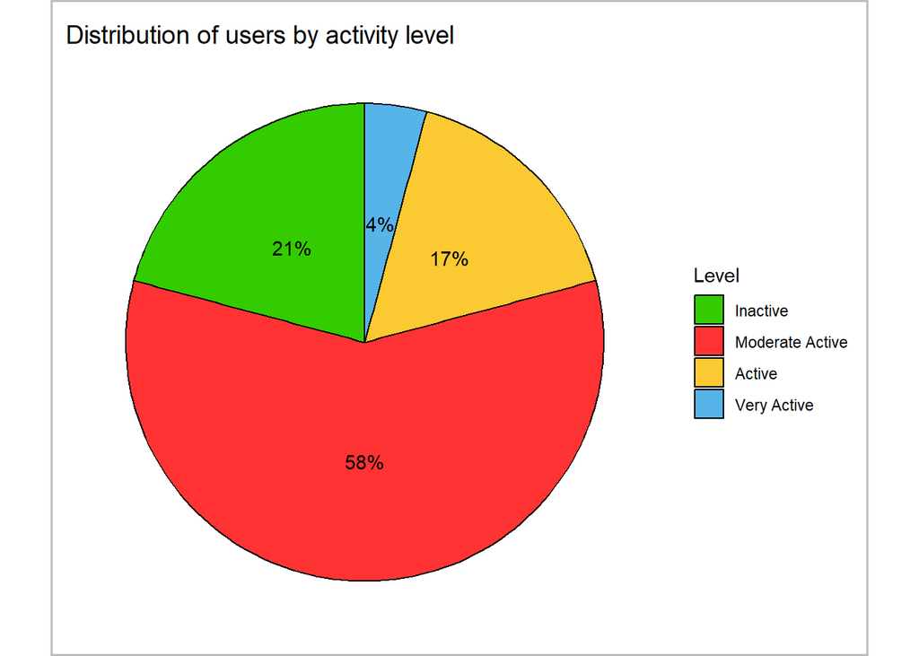

```r
#visualising the data: Distribution of users by activity level

colors <-  c("#33CC00", "#FF3333", "#FBC932", "#56B4E9")

ggplot(data = percentage_user_level, aes(x="", y = percent_by_user, fill = user_level)) +
  geom_col(color = "black") +
  coord_polar("y", start = 0) +
  geom_text(aes(label = paste0(round(percent_by_user*100), "%")),
            position = position_stack(vjust = 0.5)) +
  guides(fill = guide_legend(title = "Level")) +
  theme(panel.background = element_blank(),
        axis.line = element_blank(),
        axis.text = element_blank(),
        axis.ticks = element_blank(),
        axis.title = element_blank(),
        plot.title = element_text(vjust = -2, size = 14),
        plot.background = element_rect(color = "gray", size = 1)) +
  ggtitle("Distribution of users by activity level") +
  scale_fill_manual(values = colors)
```

**Conclusion:** As expected it is noted that the majority of users, approximately 79%, are in the inactive and moderately active category.

-**By weekday (Monday through Sunday):** In order to understand the users’ profiles and help Bellabeat’s marketing team to make decisions, it is necessary to evaluate how these users behave throughout the week and during the hours of the day. The following data will be organised in a weekday perspective for all users:

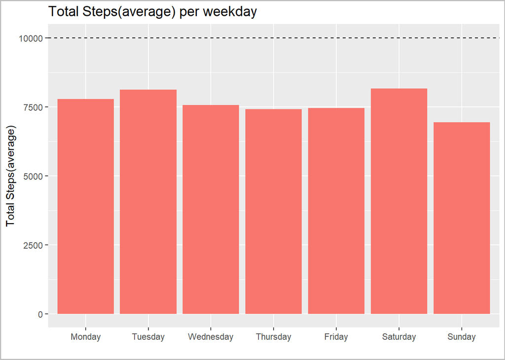

```r
#By weekday (Monday through Sunday)

weekday_total_steps <- daily_activity_clean %>%
   mutate(weekday = weekdays(ActivityDate)) %>%
   select(Id, weekday, TotalSteps) %>%
   group_by(weekday) %>%
   summarise(mean_TotalSteps = mean(TotalSteps)) %>%
   mutate(weekday = factor(weekday, levels = c('Monday', 'Tuesday', 'Wednesday', 'Thursday', 'Friday', 'Saturday', 'Sunday')))

#Visualising the data: Total Steps(average) per weekday

ggplot(weekday_total_steps, aes(x = weekday, y = mean_TotalSteps, fill = "#FFB40F"))+
   geom_bar(stat='identity') +
   geom_hline(yintercept = 10000, linetype = "dashed") +
   labs(title = "Total Steps(average) per weekday", x= "", y = "Total Steps(average)") +
   theme(legend.position="none",
         plot.title = element_text(vjust = 1, size = 14),
         plot.background = element_rect(color = "gray", size = 1))
```

**Conclusion:** It can be seen that the average number of steps taken throughout the day is below the recommended amount (10 000 per day), with the lowest average on Sunday.

In the same way we can evaluate by hour and analyse how users behave throughout the day, from the same parameter (average total steps).

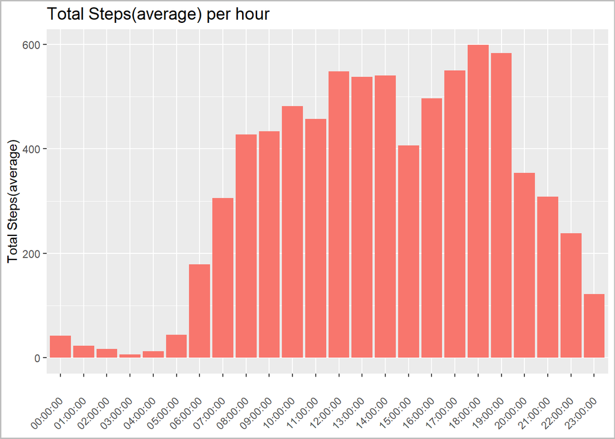

```r
#By hour

hourly_total_steps <- hourly_steps_clean %>%
  select(Id, ActivityHour, StepTotal) %>%
  group_by(ActivityHour) %>%
  summarise(mean_TotalSteps = mean(StepTotal))

#Visualising the data: Total Steps(average) per hour

ggplot(hourly_total_steps, aes(x = ActivityHour, y = mean_TotalSteps, fill = "#FFB40F"))+
  geom_bar(stat='identity') +
  labs(title = "Total Steps(average) per hour", x= "", y = "Total Steps(average)") +
  theme(legend.position="none",
        plot.title = element_text(vjust = 1, size = 14),
        plot.background = element_rect(color = "gray", size = 1)) +
  theme(axis.text.x = element_text(angle = 45,vjust = 0.5, hjust = 1))
```

- **By sleep duration (<7h, 7-9h and >9h):** To check the distribution of users in relation to sleep time, in this section we will categorise the data of asleep users in the following way [[7](https://www.sleepfoundation.org/how-sleep-works/how-much-sleep-do-we-really-need),[8](https://www.ncbi.nlm.nih.gov/pmc/articles/PMC2864873/)]:
- Short Sleep: less than 7 h
- Ideal Sleep: between 7 to 9 h
- Long Sleep: more than 9 h

From this categorisation it is possible to view the percentage of users in each category.

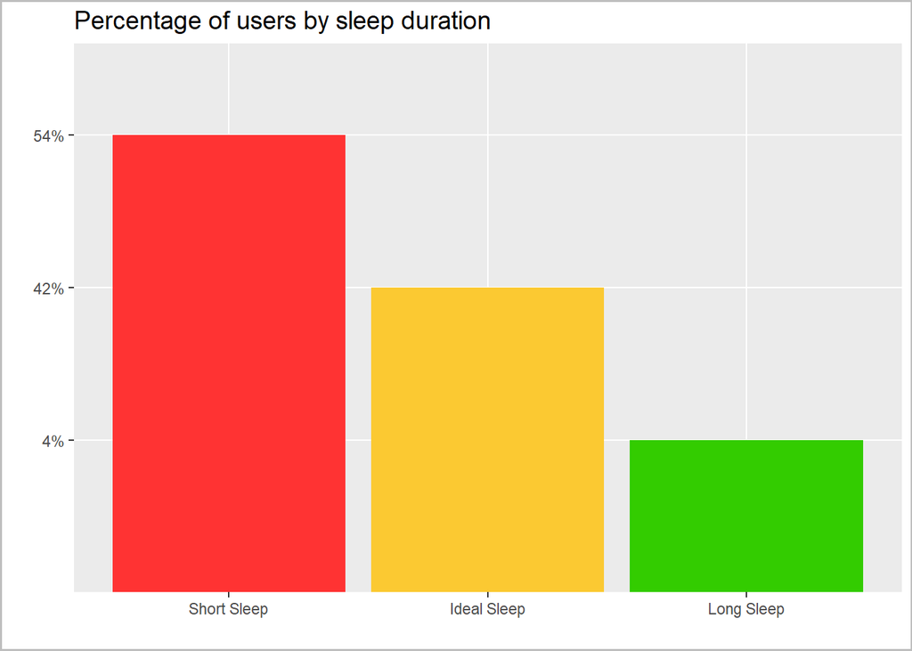

```r
#By Sleep duration

#Transforming data from data sleep

sleep_duration_by_user <- day_activity_sleep_df %>%
  select(Id, TotalMinutesAsleep, TotalTimeInBed) %>%
  mutate(Total_Asleep_Hour = TotalMinutesAsleep/60, Total_TimeInBed_Hour = TotalTimeInBed/60) %>%
  mutate(Total_Time_fall_Asleep_Minutes = (TotalTimeInBed - TotalMinutesAsleep))

#Categorising sleep data

sleep_duration_distribuition <-  sleep_duration_by_user %>%
  group_by(Id) %>%
  summarise(mean_Total_Asleep_Hour = mean(Total_Asleep_Hour)) %>%
  mutate(sleep_duration = case_when(
    mean_Total_Asleep_Hour < 7 ~ "Short Sleep",
    mean_Total_Asleep_Hour >= 7 & mean_Total_Asleep_Hour < 9 ~ "Ideal Sleep",
    mean_Total_Asleep_Hour >= 9  ~ "Long Sleep"
           ))

#Calculating the percentage of users by sleep duration

percentage_user <- sleep_duration_distribuition %>%
  group_by(sleep_duration) %>%
  summarise(percent_by_user = (n() / nrow(sleep_duration_distribuition))) %>%
  mutate(labels = scales::percent(percent_by_user)) %>%
  mutate(sleep_duration = factor(sleep_duration, levels = c('Short Sleep', 'Ideal Sleep', 'Long Sleep')))

#Visualising the data: Percentage of users by sleep duration

colors <-  c("#FF3333", "#FBC932",  "#33CC00")

ggplot(data = percentage_user, aes(x = sleep_duration,  y = labels, fill = sleep_duration)) +
    geom_col()  +
    labs(title = "Percentage of users by sleep duration", x= "", y = "") +
    theme(legend.position="none",
          plot.title = element_text(vjust = 1, size = 14),
          plot.background = element_rect(color = "gray", size = 1)) +
    guides(fill = guide_legend(title = "Duration")) +
    scale_fill_manual(values = colors)
```

**Conclusion:** From the figure it is possible to observe that 54% of users belong to the group of users who sleep less than 7h as recommended by the National Sleep Foundation guidelines.

In addition, with this data it was possible to evaluate how the users of each category sleep throughout week.

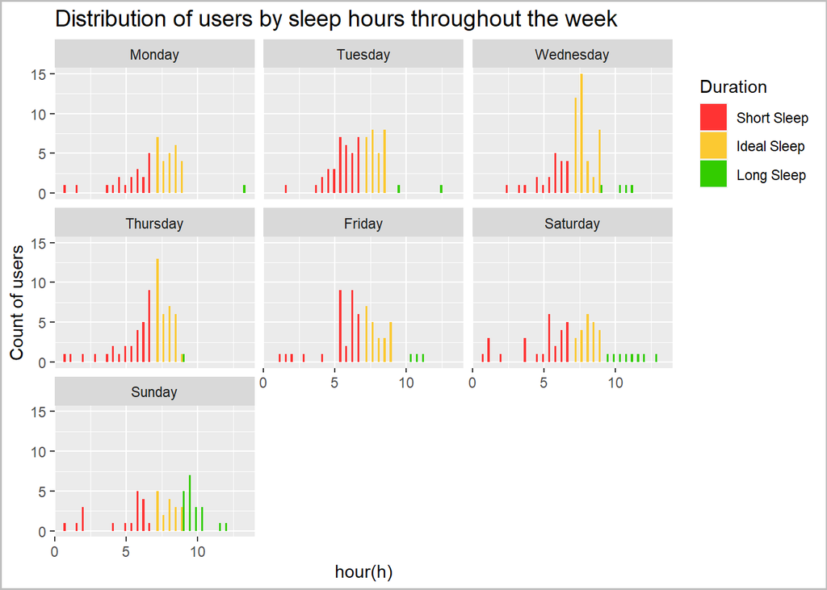

```r
#Calculating the asleep time by weekday

weekday_asleep_hour <- day_activity_sleep_df %>%
  mutate(weekday = weekdays(ActivityDate)) %>%
  select(Id, weekday, TotalMinutesAsleep) %>%
  mutate(Total_Asleep_Hour = TotalMinutesAsleep/60) %>%
  mutate(sleep_duration = case_when(
    Total_Asleep_Hour < 7 ~ "Short Sleep",
    Total_Asleep_Hour >= 7 & Total_Asleep_Hour < 9 ~ "Ideal Sleep",
    Total_Asleep_Hour >= 9  ~ "Long Sleep"
  )) %>%
  mutate(sleep_duration = factor(sleep_duration, levels = c('Short Sleep', 'Ideal Sleep', 'Long Sleep'))) %>%
  mutate(weekday = factor(weekday, levels = c('Monday', 'Tuesday', 'Wednesday', 'Thursday', 'Friday', 'Saturday', 'Sunday')))

#Visualizing the data: Distribution of users by sleep hours throughout the week

colors <-  c("#FF3333", "#FBC932",  "#33CC00")

ggplot(data = weekday_asleep_hour, aes(x = Total_Asleep_Hour, y = stat(count) , fill = sleep_duration)) +
    geom_histogram(position = 'dodge', bins = 30) +
    facet_wrap(~weekday) +
    labs(title = "Distribution of users by sleep hours throughout the week", x= "hour(h)", y = "Count of users") +
    guides(fill = guide_legend(title = "Duration")) +
    theme(legend.justification = "top",
           plot.title = element_text(vjust = 1, size = 14),
           plot.background = element_rect(color = "gray", size = 1)) +
    scale_fill_manual(values = colors)
```

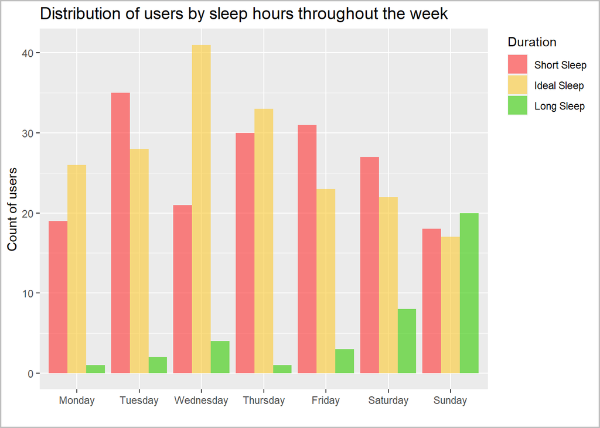

```r
ggplot(data = weekday_asleep_hour, aes(x=weekday,y = stat(count), fill=sleep_duration)) +
  geom_bar(position="dodge", alpha = 0.6) +
  labs(title = "Distribution of users by sleep hours throughout the week", x= "", y = "Count of users") +
  guides(fill = guide_legend(title = "Duration")) +
  theme(legend.justification = "top",
         plot.title = element_text(vjust = 1, size = 14),
         plot.background = element_rect(color = "gray", size = 1)) +
  scale_fill_manual(values = colors)
```

**Conclusion:** Based on the figure it can be observed that most users had short sleep (<7 h) on Tuesday, Friday and Saturday. Regarding ideal sleep, users slept between 7-9h in the middle of the week (Wednesday and Thursday) and long sleep (>9h) occurred on Sunday.

After these conclusions, we can check the data we have for any correlations, in order to investigate if there are any dependencies between the variables. Thus, we will investigate two situations:

**1. If the more steps the users do more calories are burned**

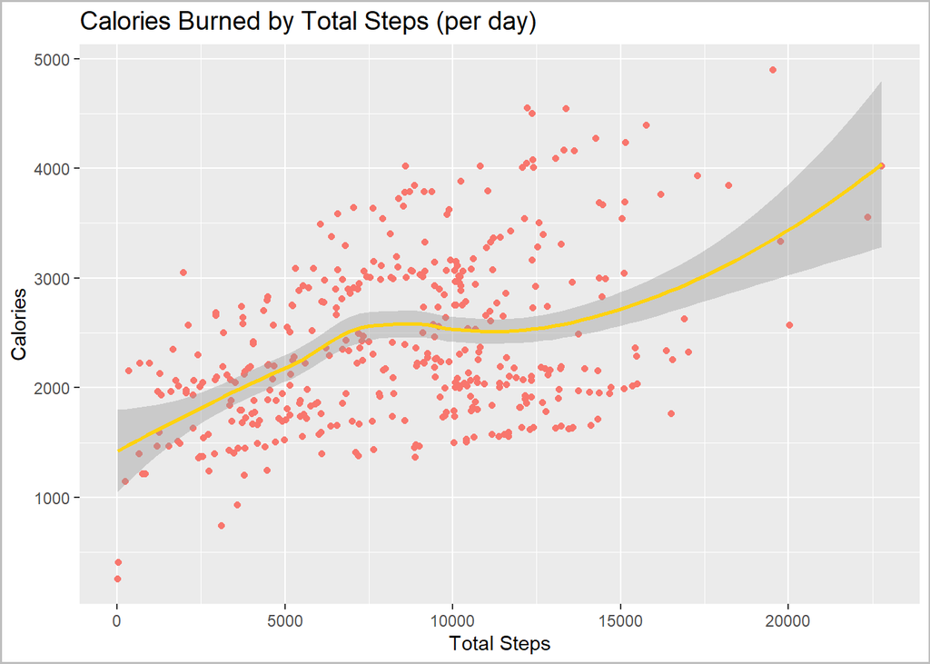

```r
#Correlation

# Calories burned vs Total steps

ggplot(data = day_activity_sleep_df, aes(x = TotalSteps, y = Calories)) +
  geom_point(color = '#F8766D') +
  geom_smooth(color = '#FFD20F') +
  labs(title = "Calories Burned by Total Steps (per day)", x= "Total Steps", y = "Calories") +
  theme(plot.title = element_text(vjust = 1, size = 14),
        plot.background = element_rect(color = "gray", size = 1))
```

**Conclusion:** we can conclude that there is a positive relationship between the total calories burned and the number of steps taken per day, i.e. the more steps a user takes per day, the more calories will be burned.

**2. If the calories expended during the day influences the time to falling asleep**

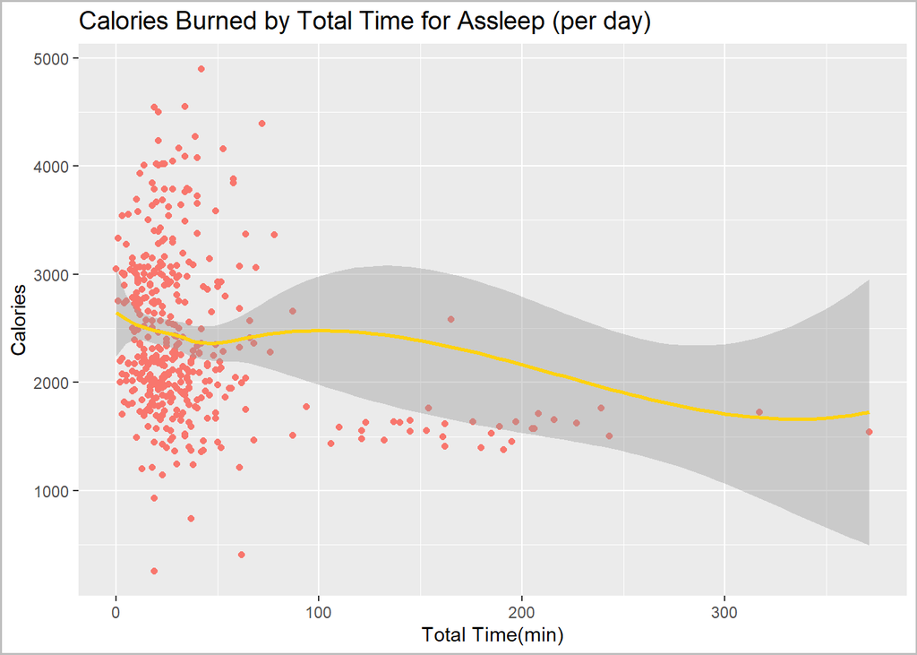

```r
# Calories burned vs Total Time Falling Asleep (per day)

# Calculating total time for Asleep

calories_sleep_df <- day_activity_sleep_df %>%
  mutate(Total_Time_fall_Asleep_Minutes = (TotalTimeInBed - TotalMinutesAsleep))

# Visualizing the data: Calories Burned by Total Time for Assleep (per day)

ggplot(data = calories_sleep_df, aes(x = Total_Time_fall_Asleep_Minutes, y = Calories), position = "jitter") +
  geom_point(color = '#F8766D') +
  geom_smooth(color = '#FFD20F') +
  labs(title = "Calories Burned by Total Time for Assleep (per day)", x= "Total Time(min)", y = "Calories") +
  theme(plot.title = element_text(vjust = 1, size = 14),
        plot.background = element_rect(color = "gray", size = 1))
```

## Act

Bellabeat’s mission is to empower women for self-awareness by helping them understand themselves in order to help them achieve their personal goals through the syncing of body, mind and cycle. In this way, from our findings on FitBit Fitness Tracker Data, we can make some recommendations for the Bellabeat App and the Bellabeat online campaign.

**Bellabeat App:**

- As it was seen that most users are in low activity category. **Bellabeat app can recommend different activities (Yoga, Walking, Running, Biking) based on the user profile in order to encourage these users to move more.** It shows for users in each activity the average caloric expenditure, the benefits obtained from it, and the amount of minutes needed to perform it in order to reach their daily goal.
- Based on the fact that users do not reach the recommended 10 000 steps per day. This can be achieved if users are more consistent throughout the day. **Bellabeat App could notify users throughout the day to get up and take some steps.** To do this **Bellabeat could not only notify users with motivational messages, but also reward them with points that could be used as a discount when purchasing new products from the brand.**
- Since more than half of the users (54%) sleep less than recommended (< 7h), **BellaBeat app could recommend users an hour before their sleep window to do relaxing activities that stimulate sleep, such as reading books, meditating, drinking tea, unplugging electronics, and others.**

## References

- *Yuenyongchaiwat K.* Effects of 10,000 steps a day on physical and mental health in overweight participants in a community setting: a preliminary study. Braz J Phys Ther. 2016 Jul-Aug;20(4):367-73. doi: 10.1590/bjpt-rbf.2014.0160. Epub 2016 Jun 16. PMID: 27556393; PMCID: PMC5015672.
- *Tudor-Locke, C., Craig, C.L., Brown, W.J. et al.* How many steps/day are enough? for adults. Int J Behav Nutr Phys Act 8, 79 (2011).
- *Hirshkowitz M, Whiton K, Albert SM, Alessi C, Bruni O, DonCarlos L, Hazen N, Herman J, Katz ES, Kheirandish-Gozal L, Neubauer DN, O’Donnell AE, Ohayon M, Peever J, Rawding R, Sachdeva RC, Setters B, Vitiello MV, Ware JC, Adams Hillard PJ.* National Sleep Foundation’s sleep time duration recommendations: methodology and results summary. Sleep Health. 2015 Mar;1(1):40-43. doi: 10.1016/j.sleh.2014.12.010. Epub 2015 Jan 8. PMID: 29073412.
- *Cappuccio FP, D’Elia L, Strazzullo P, Miller MA.* Sleep duration and all-cause mortality: a systematic review and meta-analysis of prospective studies. Sleep. 2010 May;33(5):585-92. doi: 10.1093/sleep/33.5.585. PMID: 20469800; PMCID: PMC2864873.